# Earnings and Income Inequality Across Countries

Evidence from the Luxembourg Income Study (LIS)

Published

March 6, 2026

## 1 Overview

This report summarises cross-country trends in **individual earnings inequality**, **household earnings inequality**, and **disposable household income inequality** using microdata from the Luxembourg Income Study (LIS). All series are indexed to the first available observation per country and expressed as percentage change, with a three-wave centred rolling mean overlaid.

The headline results cover **seven countries** — Brazil, Canada, Germany, Italy, Sweden, the United Kingdom, and the United States — selected because they have at least three datasets per decade since the early 1980s across all major LIS databases. For selected years in some countries, filter variables (weekly hours, weeks worked) are constructed from proxies or imputed where direct measures are unavailable.

Additional results replicate two alternative sample restrictions used in the literature (PLW and MJR) across the full set of LIS countries, and benchmark the U.S. series against the CPS ASEC.

## 2 Seven-Country Sample

The figures below apply a country-specific **core worker filter**: employed workers aged 16–64, at least 20 hours per week, at least 40 weeks per year, and an earnings floor equivalent to $4/hr in 2018 USD (converted to 2017 PPP international dollars). Where `hourstot` or `weeks` are not directly observed, country-specific proxies or imputations are used. Four inequality measures are shown for each country: Gini, P90/P10, P90/P50, and P50/P10.

Annotations in each panel show the Pearson correlation between individual labour income inequality (`pilabour`) and disposable household income inequality (`dhi`) before and after 2010. Blue = positive, red = negative, grey = insufficient data (< 3 observations).

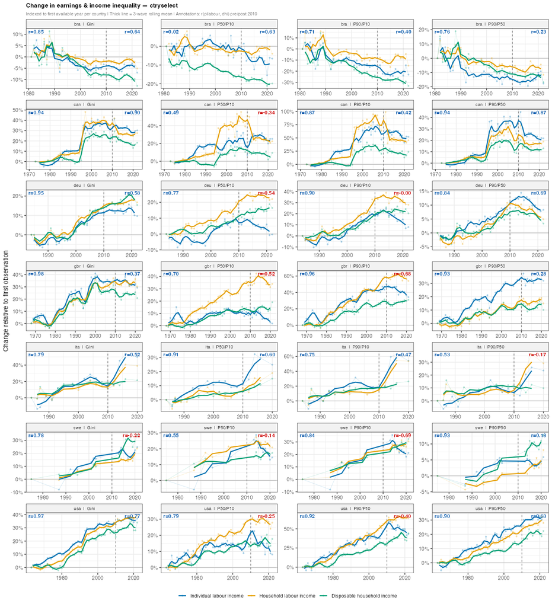

Figure 1: Core worker filter — Brazil, Canada, Germany, Italy, Sweden, UK, USA. Indexed to first available year per country.

## 3 Additional Results

### 3.1 PLW Filter — All LIS Countries

The PLW filter (Parolin, Lehner & Wilmers, 2025) applies a strict hours-and-weeks requirement across the full set of LIS countries, making the sample as comparable as possible to the CPS-based “core worker” definition. Workers must be aged 16–64 with reported hours (≥ 20 hrs/week), weeks worked (≥ 40 weeks/year), and an earnings floor equivalent to $4/hr in 2018 USD.

#### 3.1.1 Anglo-Saxon Countries

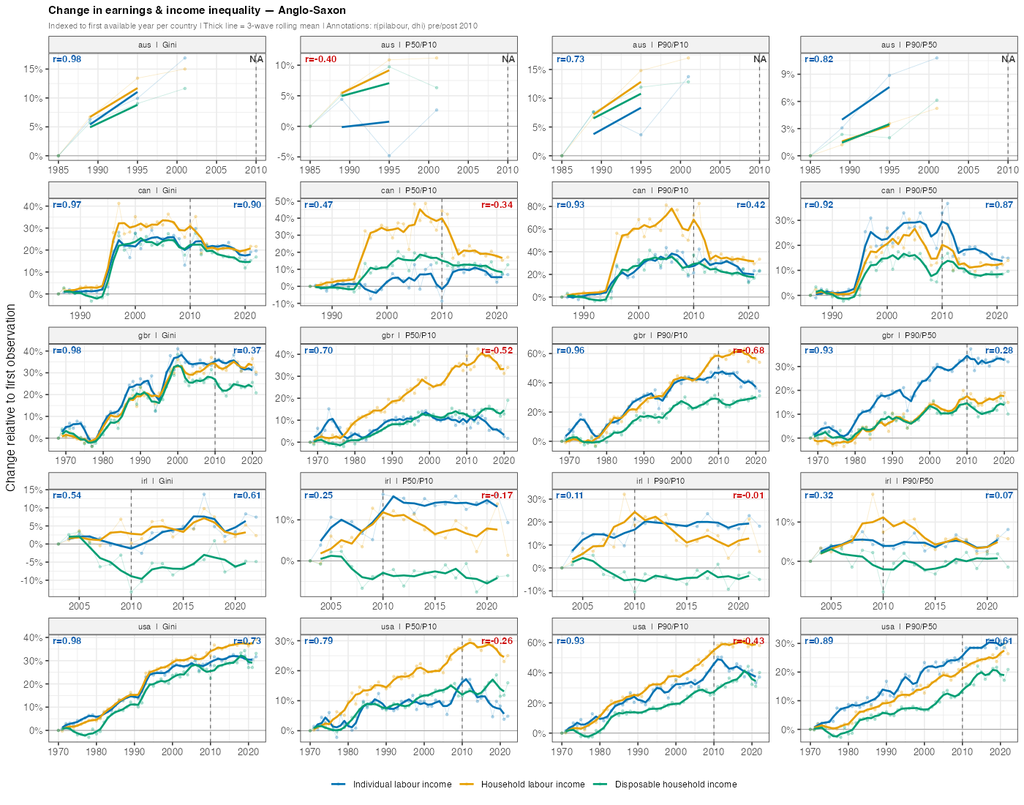

#### 3.1.2 Central Europe

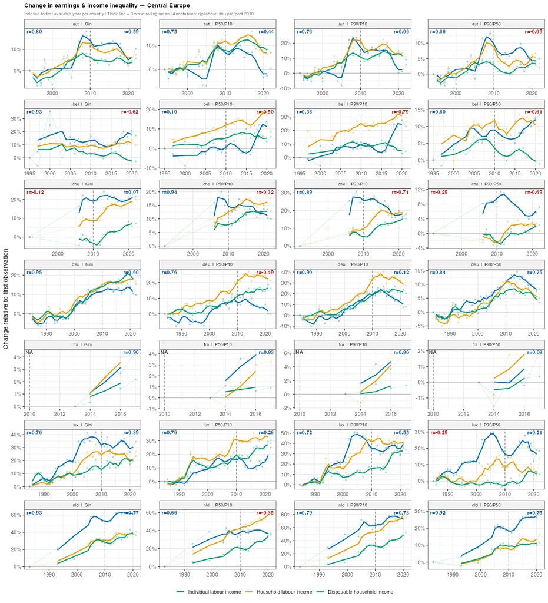

Figure 3: PLW filter — Central Europe (AUT, BEL, CHE, DEU, FRA, LUX, NLD)

#### 3.1.3 Nordic Countries

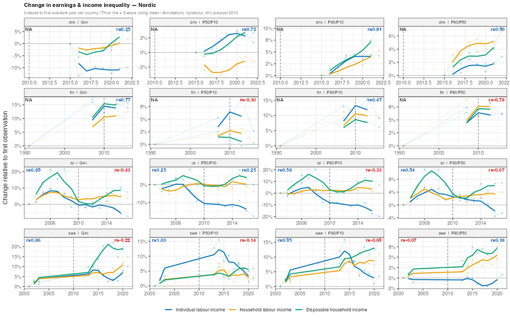

#### 3.1.4 Mediterranean Countries

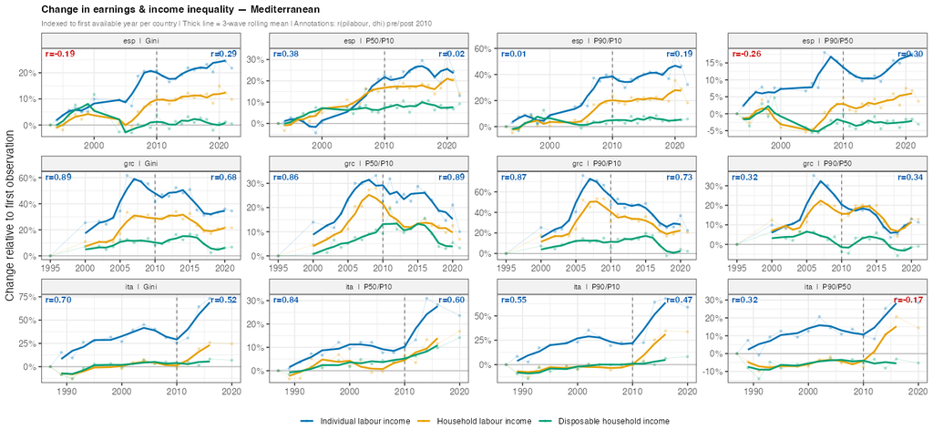

#### 3.1.5 Eastern Europe

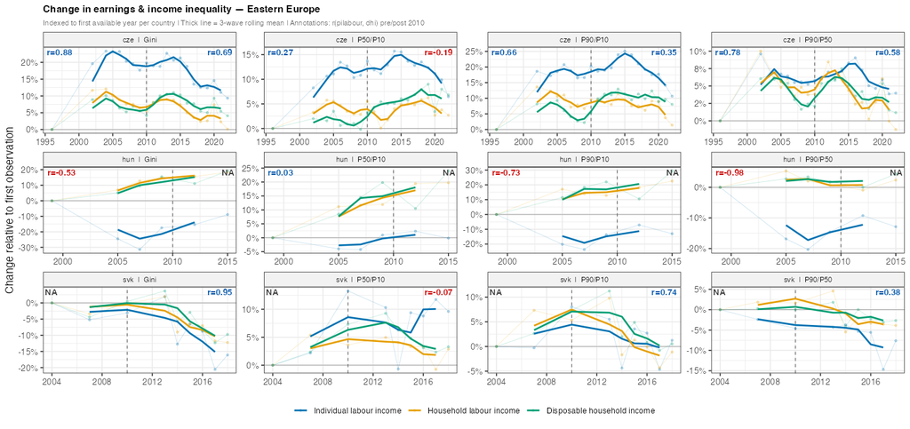

#### 3.1.6 Baltic Countries

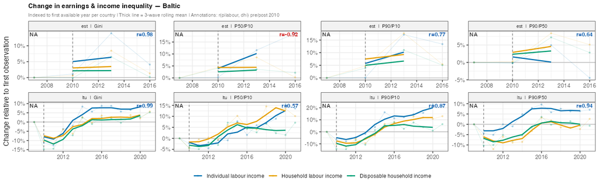

#### 3.1.7 Latin America

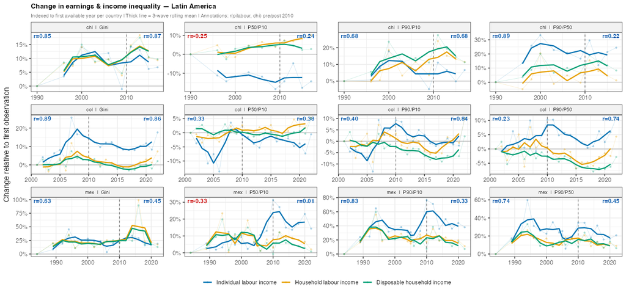

#### 3.1.8 Other

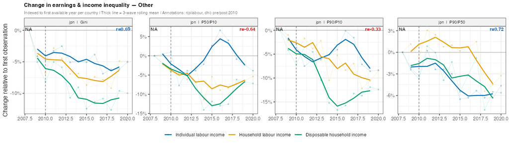

Figure 9: PLW filter — Other (JPN)

### 3.2 MJR Filter — All LIS Countries

The MJR filter (Mahler, Jesuit & Roscoe, 1999) retains all employed workers aged 16–64 with positive individual labour income (`pilabour > 0`), without additional hours or weeks restrictions. This broader definition increases coverage for countries where hours and weeks variables are missing or imputed, at the cost of including very marginal workers.

#### 3.2.1 Anglo-Saxon Countries

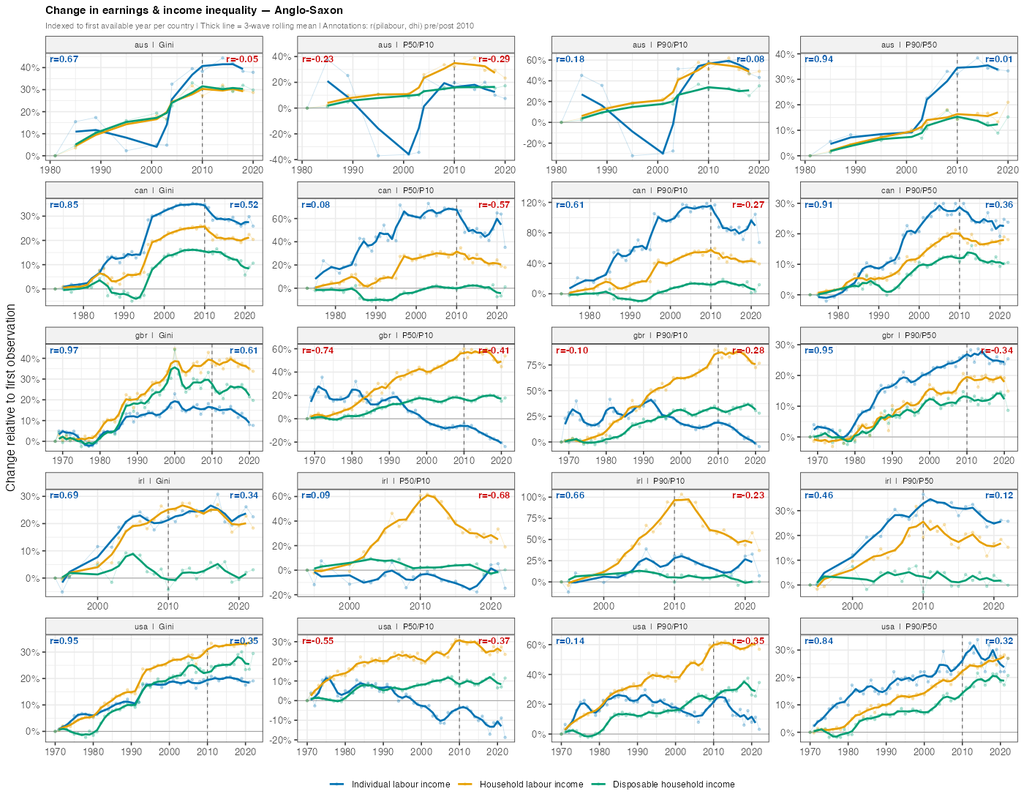

#### 3.2.2 Central Europe

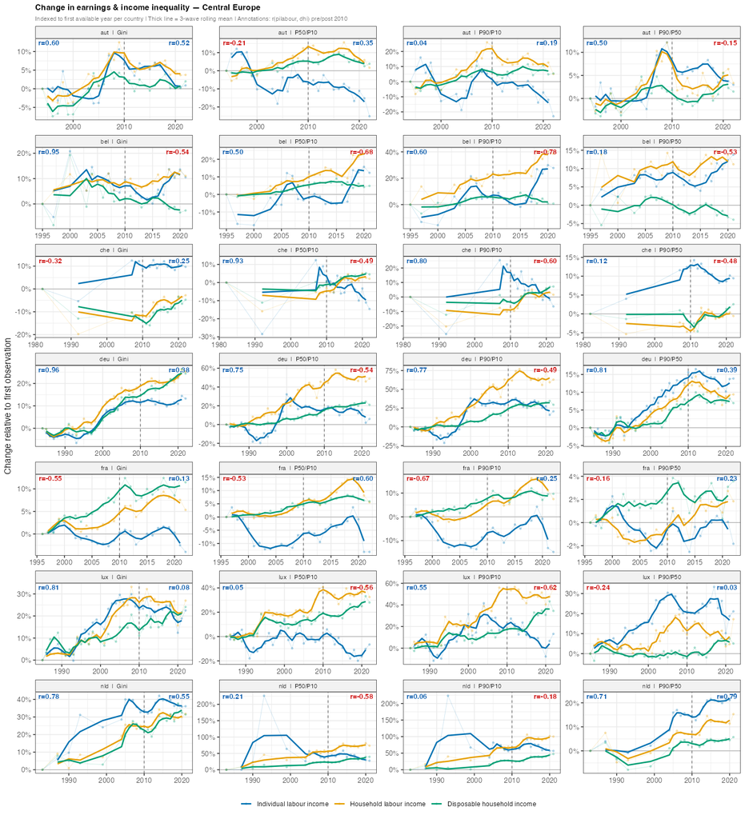

Figure 11: MJR filter — Central Europe (AUT, BEL, CHE, DEU, FRA, LUX, NLD)

#### 3.2.3 Nordic Countries

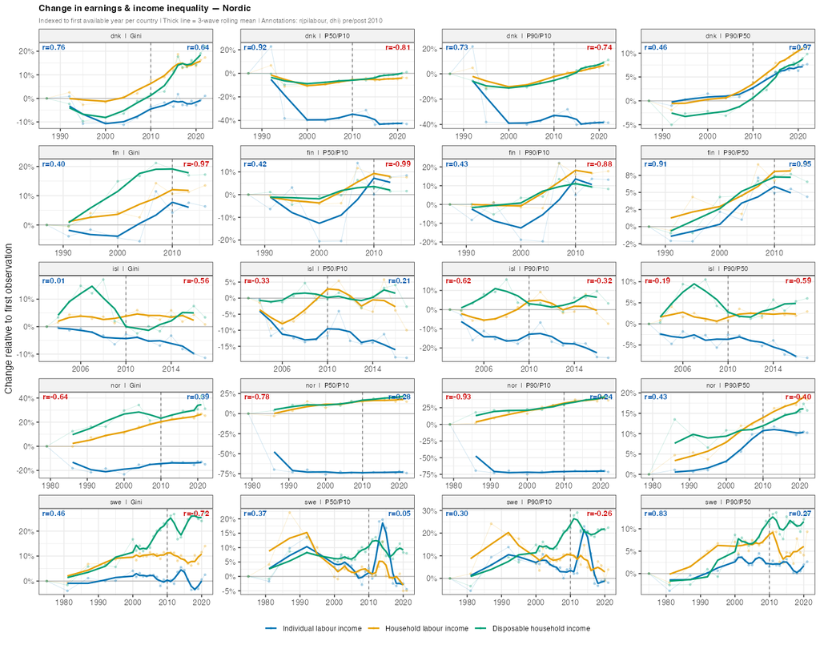

Figure 12: MJR filter — Nordic countries (DNK, FIN, ISL, NOR, SWE)

#### 3.2.4 Mediterranean Countries

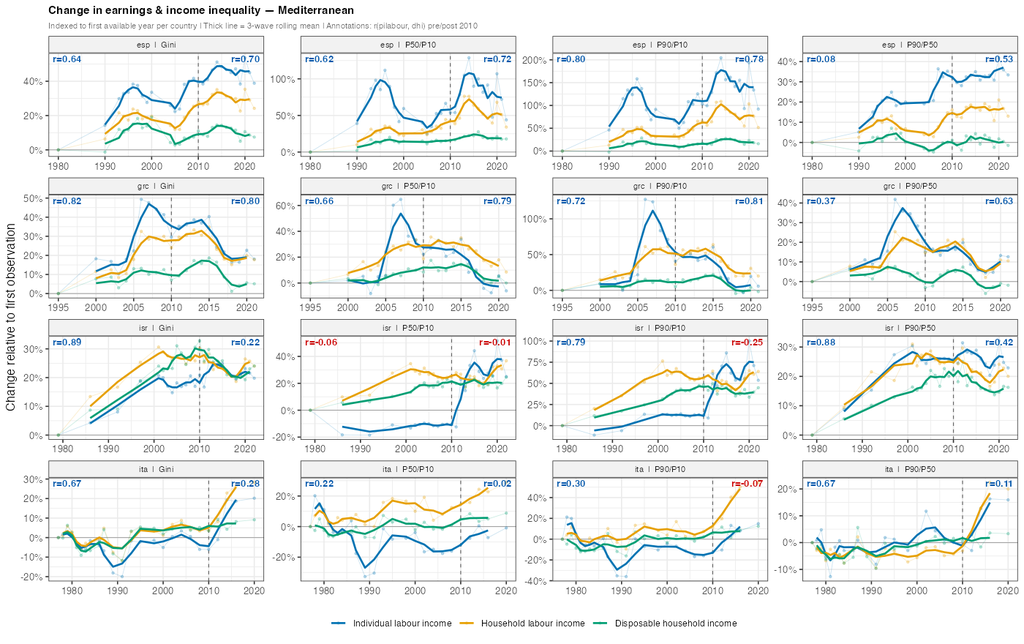

#### 3.2.5 Eastern Europe

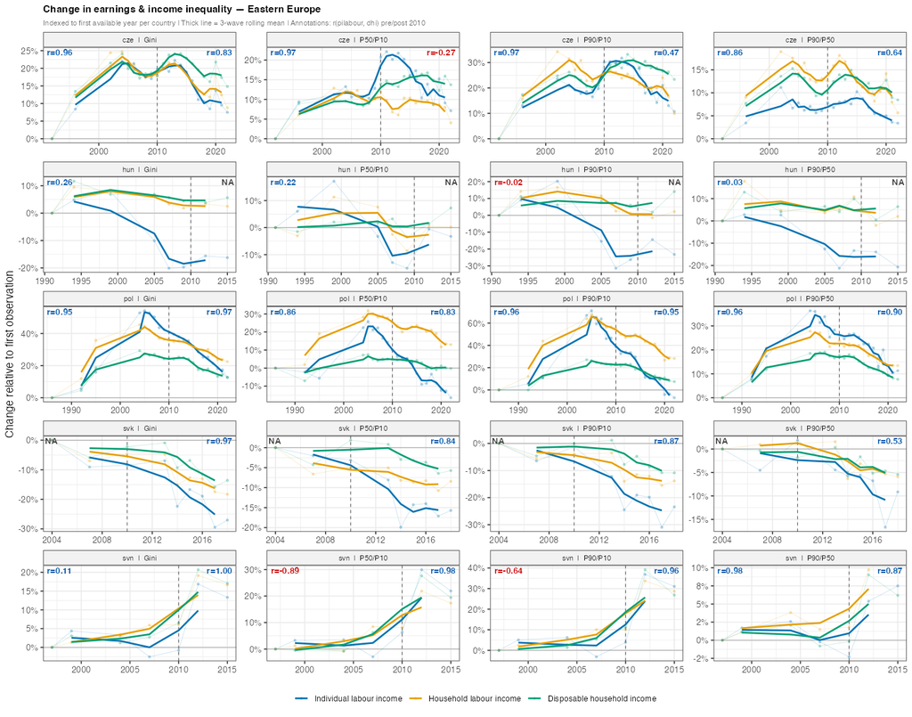

#### 3.2.6 Baltic Countries

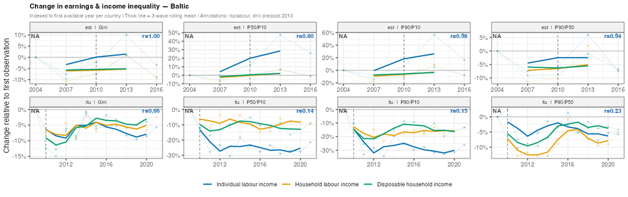

#### 3.2.7 Latin America

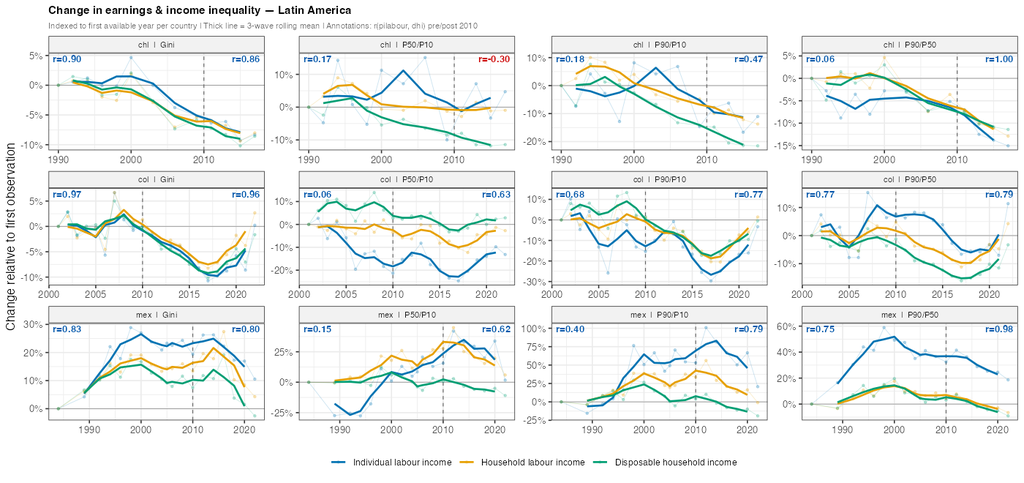

#### 3.2.8 Other

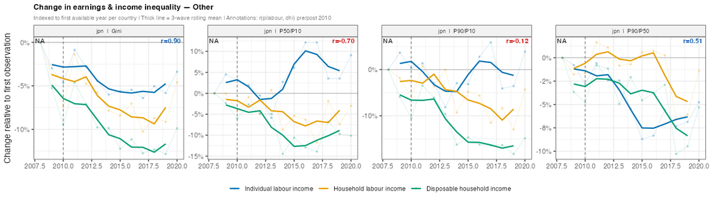

Figure 17: MJR filter — Other (JPN)

### 3.3 PLW Filter — Correlation summary

#### 3.3.1 Table

Pearson r (pilabour vs dhi, indexed growth), pre/post 2010 -- PLW

| Country | Gini Pre-2010 | Gini Post-2010 | P90/P10 Pre-2010 | P90/P10 Post-2010 | P90/P50 Pre-2010 | P90/P50 Post-2010 | P50/P10 Pre-2010 | P50/P10 Post-2010 |
| --- | --- | --- | --- | --- | --- | --- | --- | --- |
| **Anglo-Saxon** |  |  |  |  |  |  |  |  |
| aus | 0.98 | --- | 0.73 | --- | 0.82 | --- | -0.40 | --- |
| can | 0.97 | 0.90 | 0.93 | 0.42 | 0.92 | 0.87 | 0.47 | -0.34 |
| gbr | 0.98 | 0.37 | 0.96 | -0.68 | 0.93 | 0.28 | 0.70 | -0.52 |
| irl | 0.54 | 0.61 | 0.11 | -0.01 | 0.32 | 0.07 | 0.25 | -0.17 |
| usa | 0.98 | 0.73 | 0.93 | -0.43 | 0.89 | 0.61 | 0.79 | -0.26 |
| **Baltic** |  |  |  |  |  |  |  |  |
| est | --- | 0.98 | --- | 0.77 | --- | 0.64 | --- | -0.92 |
| ltu | --- | 0.99 | --- | 0.87 | --- | 0.94 | --- | 0.57 |
| **Central Europe** |  |  |  |  |  |  |  |  |
| aut | 0.80 | 0.59 | 0.76 | 0.06 | 0.66 | -0.09 | 0.75 | 0.44 |
| bel | 0.93 | -0.62 | 0.36 | -0.79 | 0.60 | -0.61 | 0.10 | -0.50 |
| che | -0.12 | 0.07 | 0.89 | -0.71 | -0.29 | -0.69 | 0.94 | -0.32 |
| deu | 0.95 | 0.60 | 0.90 | 0.12 | 0.84 | 0.75 | 0.76 | -0.49 |
| fra | --- | 0.90 | --- | 0.86 | --- | 0.68 | --- | 0.83 |
| lux | 0.76 | 0.39 | 0.72 | 0.55 | -0.29 | 0.21 | 0.76 | 0.28 |
| nld | 0.93 | 0.77 | 0.79 | 0.73 | 0.92 | 0.75 | 0.66 | -0.35 |
| **Eastern Europe** |  |  |  |  |  |  |  |  |
| cze | 0.88 | 0.69 | 0.66 | 0.35 | 0.78 | 0.58 | 0.27 | -0.19 |
| hun | -0.53 | --- | -0.73 | --- | -0.98 | --- | 0.03 | --- |
| svk | --- | 0.95 | --- | 0.74 | --- | 0.38 | --- | -0.07 |
| **Latin America** |  |  |  |  |  |  |  |  |
| chl | 0.85 | 0.87 | 0.68 | 0.68 | 0.89 | 0.22 | -0.25 | 0.24 |
| col | 0.89 | 0.86 | 0.40 | 0.84 | 0.23 | 0.74 | 0.33 | 0.38 |
| mex | 0.63 | 0.45 | 0.83 | 0.33 | 0.74 | 0.45 | -0.33 | 0.01 |
| **Mediterranean** |  |  |  |  |  |  |  |  |
| esp | -0.19 | 0.29 | 0.01 | 0.19 | -0.26 | 0.30 | 0.38 | 0.02 |
| grc | 0.89 | 0.68 | 0.87 | 0.73 | 0.32 | 0.34 | 0.86 | 0.89 |
| ita | 0.70 | 0.52 | 0.55 | 0.47 | 0.32 | -0.17 | 0.84 | 0.60 |
| **Nordic** |  |  |  |  |  |  |  |  |
| dnk | --- | 0.25 | --- | 0.81 | --- | 0.90 | --- | 0.72 |
| fin | --- | 0.77 | --- | 0.47 | --- | -0.78 | --- | -0.30 |
| isl | 0.89 | -0.43 | 0.58 | -0.33 | 0.94 | -0.67 | 0.25 | 0.25 |
| swe | 0.86 | -0.22 | 0.95 | -0.69 | -0.07 | 0.18 | 1.00 | -0.14 |
| **Other** |  |  |  |  |  |  |  |  |
| jpn | --- | 0.69 | --- | -0.33 | --- | 0.72 | --- | -0.64 |

#### 3.3.2 Figure

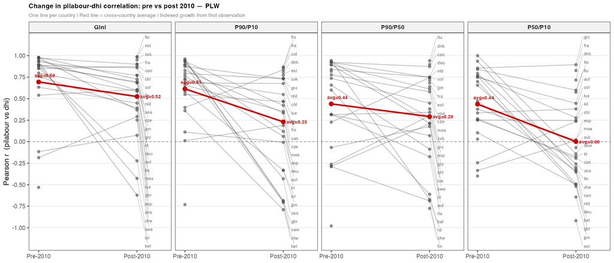

Figure 18: PLW filter — Correlations summary

### 3.4 USA: LIS vs. CPS Comparison

The figure below compares individual earnings inequality for the United States as measured by the CPS ASEC against the LIS series using the PLW filter. All series use a core-worker sample (employed, aged 16–64) and are indexed to their respective first available year. LIS years are shifted +1 to align with the CPS survey-year convention.

- **CPS ASEC**: individual market earnings from the March supplement, applying the PLW core-worker filter (age 16–64, ≥ 20 hrs/week, ≥ 40 weeks/year, earnings > $4/hr in 2018 USD).
- **LIS (PLW)**: `pilabour` with the same hours-and-weeks filter applied to LIS microdata.

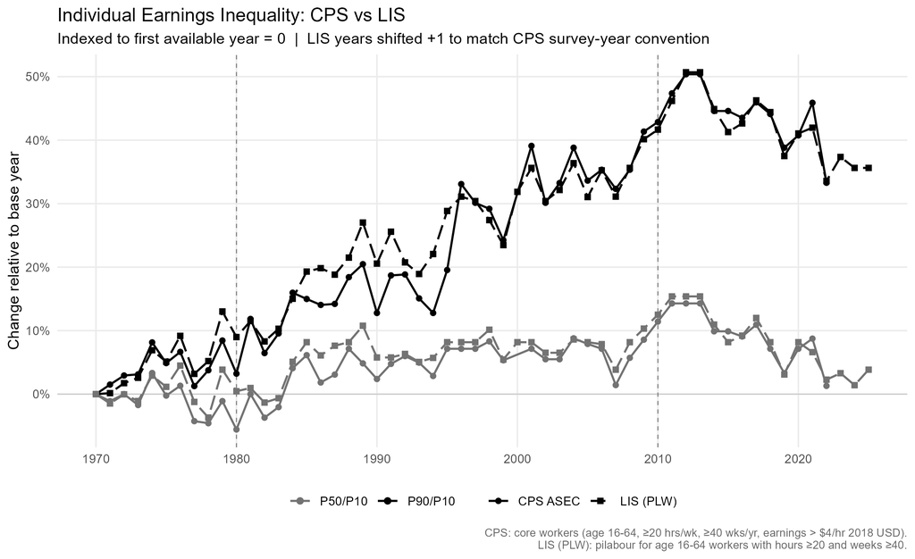

Figure 19: Individual earnings inequality (P90/P10 and P50/P10): CPS ASEC vs. LIS (PLW). Indexed to first available year = 0.